[Link to Github webpage](https://lhl10.github.io/lyrahernandezlyons10.github.io/)

# **Abortion Restrictions and Infant Deaths: A State-Level Analysis**

Lyra Hernandez Lyons

### **Dataset Sources**

[Guttmacher Institute](https://states.guttmacher.org/policies/) [CDC WONDER](https://wonder.cdc.gov/lbd-current-expanded.html) [IPUMS](https://usa.ipums.org/usa-action/)

### **Datasets in Github**

Guttmacher Institute [CDC WONDER](https://github.com/lhl10/lyrahernandezlyons10.github.io/blob/main/Datasets/Infant.txt) [IPUMS](https://github.com/lhl10/lyrahernandezlyons10.github.io/blob/main/Datasets/ipums.zip)

### **Reference for US Regions**

[Beresford Research](https://www.beresfordresearch.com/standard-ways-to-group-states-and-regions-of-us/)

# **I. Introduction**

Abortion restrictions in the U.S. have been a central issue in public policy discussions, particularly in relation to their potential impacts on health outcomes. This project explores the relationship between state-level abortion bans and infant mortality rates, utilizing multiple datasets that provide insights into abortion policies, healthcare access, and demographic factors. The core hypothesis is that states with more restrictive abortion policies experience higher infant mortality rates, due to the intersection of these policies with socioeconomic, healthcare, and demographic disparities. The significance of this analysis has increased following the *Dobbs* decision, which overturned Roe v. Wade and led to new abortion laws across various states. Understanding the impacts of these changes on infant mortality is crucial for public health policies moving forward.

Abortion policy data, which categorizes states by the severity of their abortion bans, is sourced from the Guttmacher Institute, an organization dedicated to advancing sexual and reproductive health and rights through research and analysis. Infant mortality data, including state-level statistics on deaths, births, and death rates per 1,000 live births, is derived from the CDC WONDER Linked Birth and Infant Death dataset. These datasets serve as the foundation for assessing how abortion restrictions correlate with infant mortality. In addition, data from the Integrated Public Use Microdata Series (IPUMS) will provide crucial socioeconomic, healthcare access, and demographic information, allowing for the control of confounding factors in the regression analysis. The goal is to examine whether stricter abortion bans are correlated with higher rates of infant deaths, and to identify key factors that may mediate this relationship.

## **Consideration of the Datasets**

### **Guttmacher Institute**

The Guttmacher Institute is a leading authority on reproductive health and rights, providing comprehensive data on abortion policies, contraceptive access, and related healthcare topics. For this analysis, the state-level dataset from Guttmacher categorizes states by the severity of abortion restrictions as of 2024, that range from total bans to no gestational limits. This dataset is crucial for understanding the political and legal landscape regarding abortion and its potential impact on public health outcomes, particularly infant mortality.

### **CDC WONDER (Centers for Disease Control and Prevention Wide-ranging Online Data for Epidemiologic Research)**

The CDC WONDER platform offers a rich query system for accessing public health data, enabling detailed analysis of health trends across the U.S. For this project, the Linked Birth and Infant Death dataset from CDC WONDER is used to examine the correlation between abortion restrictions and infant mortality rates. This dataset provides comprehensive statistics on infant deaths, live births, and death rates per 1,000 live births from 2017 to 2022, offering essential information for understanding maternal and child health outcomes.

### **IPUMS (Integrated Public Use Microdata Series)**

IPUMS provides access to detailed U.S. census data, offering key insights into socioeconomic status, healthcare access, and demographic characteristics. These data are vital for controlling for other factors that could influence infant mortality, such as household income, education levels, healthcare coverage, and employment status. By linking this dataset with the abortion policy and infant mortality data, it becomes possible to examine the direct and indirect effects of abortion restrictions on health outcomes, while accounting for socio-economic and healthcare disparities across states.

# **II. The Public Health Implications of Abortion Policy**

The consequences of abortion policies extend far beyond the immediate scope of reproductive health, affecting the well-being of infants and newborns. Stricter abortion laws, particularly those implemented after the *Dobbs* decision, have been linked to increased infant mortality rates, as highlighted in studies such as Moayedi et al. (2024) and Singh & Gallo (2024). These studies reveal that abortion restrictions not only jeopardize the health of those who are pregnant but also pose risks to the infants who are born under these policies, contributing to poorer health outcomes. A recent article by Chapman (2023) underscores the rise in infant deaths in Texas following the implementation of stricter abortion laws, demonstrating how such policies can directly impact infant mortality. The analysis of these policies shows that restrictive abortion laws exacerbate existing healthcare inequalities, particularly in regions with limited access to maternal care. By exploring the interplay between abortion laws, socioeconomic factors, and healthcare access, we can better understand the public health ramifications and the need for evidence-based policymaking that prioritizes the health of both mothers and infants.

# **III. ETL (Extraction, Transform, and Load)**

## **1. Data Extraction**

### **1.1 Guttmacher Data: Abortion Bans by State**

The state-level abortion policy dataset is sourced from an Excel file stored in Google Drive. The file is accessed in Google Colab by mounting the Google Drive and setting the appropriate working directory. The pandas library is then used to load the dataset into a DataFrame for processing.

```python
# Mounting Google Drive to access files stored there
from google.colab import drive
drive.mount('/content/drive')
```

```python
# Importing the pandas library for data manipulation and analysis
import pandas as pd

# Changing the current working directory to the specified folder in Google Drive
%cd '/content/drive/MyDrive'

# Loading the Excel file into a pandas DataFrame
gd = pd.read_excel("data.xlsx")

# Displaying the first few rows of the DataFrame to preview the data
gd.head()
```

```
/content/drive/MyDrive
```

|  | State | Abortion Ban Category | Number of States | Description |
| --- | --- | --- | --- | --- |
| 0 | Alabama | Total abortion ban | 13 | 13 states are enforcing a total abortion ban w... |
| 1 | Arkansas | Total abortion ban | 13 | 13 states are enforcing a total abortion ban w... |
| 2 | Idaho | Total abortion ban | 13 | 13 states are enforcing a total abortion ban w... |
| 3 | Indiana | Total abortion ban | 13 | 13 states are enforcing a total abortion ban w... |
| 4 | Kentucky | Total abortion ban | 13 | 13 states are enforcing a total abortion ban w... |

### **1.2 CDC WONDER: Linked Infant Birth / Death Records**

The CDC WONDER dataset, downloaded as a tab-delimited text file, is loaded into a pandas DataFrame for analysis.

```python
# Reading the CDC WONDER data file as a tab-delimited text file
cdc = pd.read_csv('Infant.txt', delimiter='\t', skiprows=1, header=None)
cdc.head()
```

|  | 0 | 1 | 2 | 3 | 4 | 5 |
| --- | --- | --- | --- | --- | --- | --- |
| 0 | NaN | Alabama | 1.0 | 389.0 | 58149.0 | 6.69 |
| 1 | NaN | Alaska | 2.0 | 62.0 | 9359.0 | 6.62 |
| 2 | NaN | Arizona | 4.0 | 485.0 | 78547.0 | 6.17 |
| 3 | NaN | Arkansas | 5.0 | 272.0 | 35471.0 | 7.67 |
| 4 | NaN | California | 6.0 | 1724.0 | 419104.0 | 4.11 |

### **1.3 IPUMS: Socioeconomic and Demographic Variables**

An extract of American Census Survey data from IPUMS for 2022, downloaded as a zipped .csv file, is loaded into a pandas DataFrame for analysis.

```python
import gzip
import shutil

# Path to uploaded .gz file
gz_file_path = "IPUMS.gz"

# Decompressing the .gz file
with gzip.open(gz_file_path, 'rb') as f_in:
    with open('IPUMS', 'wb') as f_out:
        shutil.copyfileobj(f_in, f_out)

# Loading the .csv file using pandas
ipums = pd.read_csv('IPUMS')

# Showing the first few rows of the Dataframe
ipums.head()
```

|  | YEAR | STATEFIP | HHINCOME | SEX | AGE | RACE | RACED | HISPAN | HISPAND | HCOVPRIV | HINSEMP | HCOVPUB | HINSCAID | HINSCARE | EDUC | EDUCD | EMPSTAT | EMPSTATD | INCTOT |
| --- | --- | --- | --- | --- | --- | --- | --- | --- | --- | --- | --- | --- | --- | --- | --- | --- | --- | --- | --- |
| 0 | 2022 | 1 | 9999999 | 2 | 85 | 8 | 801 | 0 | 0 | 1 | 1 | 2 | 2 | 2 | 7 | 71 | 3 | 30 | 18800 |
| 1 | 2022 | 1 | 9999999 | 1 | 51 | 1 | 100 | 0 | 0 | 1 | 1 | 2 | 1 | 2 | 6 | 64 | 3 | 30 | 12500 |
| 2 | 2022 | 1 | 9999999 | 2 | 36 | 2 | 200 | 0 | 0 | 1 | 1 | 2 | 2 | 1 | 2 | 26 | 3 | 30 | 16400 |
| 3 | 2022 | 1 | 9999999 | 1 | 74 | 2 | 200 | 0 | 0 | 1 | 1 | 2 | 2 | 2 | 0 | 2 | 3 | 30 | 8600 |
| 4 | 2022 | 1 | 9999999 | 1 | 49 | 1 | 100 | 0 | 0 | 1 | 1 | 1 | 1 | 1 | 7 | 71 | 3 | 30 | 5000 |

## **2. Data Transformation**

### **2.1 Guttmacher Data: Abortion Bans by State**

The Guttmacher dataframe is cleaned and streamlined by removing unnecessary columns, such as descriptions and state counts, and categorical abortion policy data is mapped to numerical values. This process ensures the dataset is structured and ready for quantitative analysis and further exploration.

```python
# Dropping unnecessary columns to focus the analysis
# "Description" and "Number of States" are not relevant for this analysis
columns_to_drop = ["Description", "Number of States"]
gd = gd.drop(columns=columns_to_drop)

# Fixing States with *
gd["State"] = gd["State"].str.replace("*", "", regex=False)

# Changing DC to District of Columbia
gd["State"] = gd["State"].replace("DC", "District of Columbia")

# Mapping abortion ban categories to numerical values for easier analysis
# Each category is assigned a unique integer for quantitative evaluation
ban_mapping = {
    "Total abortion ban": 7, "6-week ban": 6, "12-week ban": 5,
    "15-week ban": 4, "18-23-week ban": 3, "24-26-week ban": 2,
    "No gestational ban": 1}

# Creating a new column with numerical representations of abortion ban categories
gd["AbortionBanNum"] = gd["Abortion Ban Category"].map(ban_mapping)

# Displaying the first few rows of the DataFrame to verify changes
gd.head()
```

|  | State | Abortion Ban Category | AbortionBanNum |
| --- | --- | --- | --- |
| 0 | Alabama | Total abortion ban | 7 |
| 1 | Arkansas | Total abortion ban | 7 |
| 2 | Idaho | Total abortion ban | 7 |
| 3 | Indiana | Total abortion ban | 7 |
| 4 | Kentucky | Total abortion ban | 7 |

### **2.2 CDC WONDER: Linked Infant Birth / Death Records**

After reading the data, the appropriate column names are manually assigned for clarity. Numeric columns, such as "Deaths," "Births," and "Death Rate," are converted to numeric data types to ensure accuracy in calculations. The "Notes" column, deemed unnecessary for this analysis, is removed to streamline the dataset. This cleaning process ensures the data is prepared for meaningful analysis and integration with other datasets.

```python
# Manually setting the correct column names for clarity and usability
cdc.columns = ["Notes", "State", "State Code", "Deaths", "Births", "Death Rate"]

# Converting numeric columns to the appropriate data type for analysis
for col in ["Deaths", "Births", "Death Rate"]:
    cdc[col] = pd.to_numeric(cdc[col], errors='coerce')

# Dropping the 'Notes' column as it contains irrelevant or redundant information
cdc.drop(columns=["Notes"], inplace=True)

# Displaying the cleaned DataFrame
cdc.head()
```

|  | State | State Code | Deaths | Births | Death Rate |
| --- | --- | --- | --- | --- | --- |
| 0 | Alabama | 1.0 | 389.0 | 58149.0 | 6.69 |
| 1 | Alaska | 2.0 | 62.0 | 9359.0 | 6.62 |
| 2 | Arizona | 4.0 | 485.0 | 78547.0 | 6.17 |
| 3 | Arkansas | 5.0 | 272.0 | 35471.0 | 7.67 |
| 4 | California | 6.0 | 1724.0 | 419104.0 | 4.11 |

### **2.3 IPUMS: Socioeconomic and Demographic Variables**

#### **IPUMS: STATE**

Once the IPUMS file is uploaded, the `STATEFIP` column is used to map FIPS codes to their respective state names through a predefined dictionary. This replaces the numeric codes with state names, enhancing the dataset's readability and suitability for state-level analysis.

```python
# Creating FIPS code to state name mapping
fips_to_state = {
    1: 'Alabama', 2: 'Alaska', 4: 'Arizona', 5: 'Arkansas', 6: 'California',
    8: 'Colorado', 9: 'Connecticut', 10: 'Delaware', 11: 'District of Columbia',
    12: 'Florida', 13: 'Georgia', 15: 'Hawaii', 16: 'Idaho', 17: 'Illinois',
    18: 'Indiana', 19: 'Iowa', 20: 'Kansas', 21: 'Kentucky', 22: 'Louisiana',
    23: 'Maine', 24: 'Maryland', 25: 'Massachusetts', 26: 'Michigan', 27: 'Minnesota',
    28: 'Mississippi', 29: 'Missouri', 30: 'Montana', 31: 'Nebraska', 33: 'Nevada',
    34: 'New Hampshire', 35: 'New Jersey', 36: 'New Mexico', 37: 'New York',
    38: 'North Carolina', 39: 'North Dakota', 40: 'Ohio', 41: 'Oklahoma', 42: 'Oregon',
    44: 'Pennsylvania', 45: 'Rhode Island', 46: 'South Carolina', 47: 'South Dakota',
    48: 'Tennessee', 49: 'Texas', 50: 'Utah', 51: 'Vermont', 53: 'Virginia', 54: 'Washington',
    55: 'West Virginia', 56: 'Wisconsin', 57: 'Wyoming'
}

# Ensuring the 'STATEFIP' column exists and mapping FIPS codes to state names
if 'STATEFIP' in ipums.columns:
    ipums['State'] = ipums['STATEFIP'].map(fips_to_state)

ipums.head()
```

|  | YEAR | STATEFIP | HHINCOME | SEX | AGE | RACE | RACED | HISPAN | HISPAND | HCOVPRIV | HINSEMP | HCOVPUB | HINSCAID | HINSCARE | EDUC | EDUCD | EMPSTAT | EMPSTATD | INCTOT | State |
| --- | --- | --- | --- | --- | --- | --- | --- | --- | --- | --- | --- | --- | --- | --- | --- | --- | --- | --- | --- | --- |
| 0 | 2022 | 1 | 9999999 | 2 | 85 | 8 | 801 | 0 | 0 | 1 | 1 | 2 | 2 | 2 | 7 | 71 | 3 | 30 | 18800 | Alabama |
| 1 | 2022 | 1 | 9999999 | 1 | 51 | 1 | 100 | 0 | 0 | 1 | 1 | 2 | 1 | 2 | 6 | 64 | 3 | 30 | 12500 | Alabama |
| 2 | 2022 | 1 | 9999999 | 2 | 36 | 2 | 200 | 0 | 0 | 1 | 1 | 2 | 2 | 1 | 2 | 26 | 3 | 30 | 16400 | Alabama |
| 3 | 2022 | 1 | 9999999 | 1 | 74 | 2 | 200 | 0 | 0 | 1 | 1 | 2 | 2 | 2 | 0 | 2 | 3 | 30 | 8600 | Alabama |
| 4 | 2022 | 1 | 9999999 | 1 | 49 | 1 | 100 | 0 | 0 | 1 | 1 | 1 | 1 | 1 | 7 | 71 | 3 | 30 | 5000 | Alabama |

#### **IPUMS: SEX**

The `female` column is created by applying a transformation to the `SEX` column, where a value of 1 is assigned for females and 0 for others. The `female_rate` is then calculated by grouping the data by state and determining the mean of the `female` column within each state. This calculation provides the percentage of women in each state.

```python
# Calculating the percentage of females in each state (based on SEX column)
ipums['female'] = ipums['SEX'].apply(lambda x: 1 if x == 2 else 0)  # Proportion female
ipums['female_rate'] = ipums.groupby('State')['female'].transform('mean')

ipums.head()
```

|  | YEAR | STATEFIP | HHINCOME | SEX | AGE | RACE | RACED | HISPAN | HISPAND | HCOVPRIV | ... | HINSCAID | HINSCARE | EDUC | EDUCD | EMPSTAT | EMPSTATD | INCTOT | State | female | female_rate |
| --- | --- | --- | --- | --- | --- | --- | --- | --- | --- | --- | --- | --- | --- | --- | --- | --- | --- | --- | --- | --- | --- |
| 0 | 2022 | 1 | 9999999 | 2 | 85 | 8 | 801 | 0 | 0 | 1 | ... | 2 | 2 | 7 | 71 | 3 | 30 | 18800 | Alabama | 1 | 0.515297 |
| 1 | 2022 | 1 | 9999999 | 1 | 51 | 1 | 100 | 0 | 0 | 1 | ... | 1 | 2 | 6 | 64 | 3 | 30 | 12500 | Alabama | 0 | 0.515297 |
| 2 | 2022 | 1 | 9999999 | 2 | 36 | 2 | 200 | 0 | 0 | 1 | ... | 2 | 1 | 2 | 26 | 3 | 30 | 16400 | Alabama | 1 | 0.515297 |
| 3 | 2022 | 1 | 9999999 | 1 | 74 | 2 | 200 | 0 | 0 | 1 | ... | 2 | 2 | 0 | 2 | 3 | 30 | 8600 | Alabama | 0 | 0.515297 |
| 4 | 2022 | 1 | 9999999 | 1 | 49 | 1 | 100 | 0 | 0 | 1 | ... | 1 | 1 | 7 | 71 | 3 | 30 | 5000 | Alabama | 0 | 0.515297 |

5 rows × 22 columns

#### **IPUMS: AGE**

```python
# Calculate the percentage of women aged 15-44 in each state
ipums['age_15_44'] = ipums['AGE'].apply(lambda x: 1 if 15 <= x <= 44 else 0)  # Mark age 15-44
ipums['age_rate'] = ipums.groupby('State')['age_15_44'].transform('mean')  # Proportion of women aged 15-44 by state

ipums.head()
```

|  | YEAR | STATEFIP | HHINCOME | SEX | AGE | RACE | RACED | HISPAN | HISPAND | HCOVPRIV | ... | EDUC | EDUCD | EMPSTAT | EMPSTATD | INCTOT | State | female | female_rate | age_15_44 | age_rate |
| --- | --- | --- | --- | --- | --- | --- | --- | --- | --- | --- | --- | --- | --- | --- | --- | --- | --- | --- | --- | --- | --- |
| 0 | 2022 | 1 | 9999999 | 2 | 85 | 8 | 801 | 0 | 0 | 1 | ... | 7 | 71 | 3 | 30 | 18800 | Alabama | 1 | 0.515297 | 0 | 0.338891 |
| 1 | 2022 | 1 | 9999999 | 1 | 51 | 1 | 100 | 0 | 0 | 1 | ... | 6 | 64 | 3 | 30 | 12500 | Alabama | 0 | 0.515297 | 0 | 0.338891 |
| 2 | 2022 | 1 | 9999999 | 2 | 36 | 2 | 200 | 0 | 0 | 1 | ... | 2 | 26 | 3 | 30 | 16400 | Alabama | 1 | 0.515297 | 1 | 0.338891 |
| 3 | 2022 | 1 | 9999999 | 1 | 74 | 2 | 200 | 0 | 0 | 1 | ... | 0 | 2 | 3 | 30 | 8600 | Alabama | 0 | 0.515297 | 0 | 0.338891 |
| 4 | 2022 | 1 | 9999999 | 1 | 49 | 1 | 100 | 0 | 0 | 1 | ... | 7 | 71 | 3 | 30 | 5000 | Alabama | 0 | 0.515297 | 0 | 0.338891 |

5 rows × 24 columns

#### **IPUMS: RACE & HISPANIC**

The race distribution is calculated by grouping the data by state and determining the proportion of individuals in each racial category, including White, Black, Asian, and Other races, based on the `RACE` column. Similarly, the `hispanic_rate` is calculated by grouping the data by state and determining the proportion of individuals with Hispanic origin using the `HISPAN` column. These calculations provide the racial and ethnic composition for each state.

```python
# Calculating race distribution by state (e.g., White, Black, Asian, etc.)
ipums['white_rate'] = ipums.groupby('State')['RACE'].transform(lambda x: (x == 1).mean())  # Proportion White
ipums['black_rate'] = ipums.groupby('State')['RACE'].transform(lambda x: (x == 2).mean())  # Proportion Black
ipums['asian_rate'] = ipums.groupby('State')['RACE'].transform(lambda x: (x == 3).mean())  # Proportion Asian
ipums['other_race_rate'] = ipums.groupby('State')['RACE'].transform(lambda x: (x == 4).mean())  # Proportion Other Race

# Calculating the percentage of people with Hispanic origin by state
ipums['hispanic_rate'] = ipums.groupby('State')['HISPAN'].transform(lambda x: (x == 2).mean())  # Proportion Hispanic

ipums.head()
```

|  | YEAR | STATEFIP | HHINCOME | SEX | AGE | RACE | RACED | HISPAN | HISPAND | HCOVPRIV | ... | State | female | female_rate | age_15_44 | age_rate | white_rate | black_rate | asian_rate | other_race_rate | hispanic_rate |
| --- | --- | --- | --- | --- | --- | --- | --- | --- | --- | --- | --- | --- | --- | --- | --- | --- | --- | --- | --- | --- | --- |
| 0 | 2022 | 1 | 9999999 | 2 | 85 | 8 | 801 | 0 | 0 | 1 | ... | Alabama | 1 | 0.515297 | 0 | 0.338891 | 0.710081 | 0.196588 | 0.006747 | 0.00285 | 0.003703 |
| 1 | 2022 | 1 | 9999999 | 1 | 51 | 1 | 100 | 0 | 0 | 1 | ... | Alabama | 0 | 0.515297 | 0 | 0.338891 | 0.710081 | 0.196588 | 0.006747 | 0.00285 | 0.003703 |
| 2 | 2022 | 1 | 9999999 | 2 | 36 | 2 | 200 | 0 | 0 | 1 | ... | Alabama | 1 | 0.515297 | 1 | 0.338891 | 0.710081 | 0.196588 | 0.006747 | 0.00285 | 0.003703 |
| 3 | 2022 | 1 | 9999999 | 1 | 74 | 2 | 200 | 0 | 0 | 1 | ... | Alabama | 0 | 0.515297 | 0 | 0.338891 | 0.710081 | 0.196588 | 0.006747 | 0.00285 | 0.003703 |
| 4 | 2022 | 1 | 9999999 | 1 | 49 | 1 | 100 | 0 | 0 | 1 | ... | Alabama | 0 | 0.515297 | 0 | 0.338891 | 0.710081 | 0.196588 | 0.006747 | 0.00285 | 0.003703 |

5 rows × 29 columns

#### **IPUMS: HEALTHCARE**

The `hc` column is created by applying a function that categorizes individuals into three healthcare categories: Private Insurance, Medicaid, or No Healthcare, based on the `HCOVPRIV` and `HINSCAID` columns. Afterward, the proportion of each healthcare category (No healthcare, Private insurance, Medicaid) is calculated by grouping the data by state and determining the mean for each category. These calculations provide the healthcare coverage distribution by state.

```python
# Creating the 'Healthcare' column with 3 categories: Private, Medicaid, No healthcare
def categorize_healthcare(row):
    if row['HCOVPRIV'] == 2:  # Private health insurance
        return 1  # Private Insurance
    elif row['HINSCAID'] == 2:  # Medicaid coverage
        return 2  # Medicaid
    else:
        return 0  # No healthcare coverage

# Applying the function to the dataframe
ipums['hc'] = ipums.apply(categorize_healthcare, axis=1)

# Calculating the proportion of each healthcare category by state
ipums['hc_no'] = ipums.groupby('State')['hc'].transform(lambda x: (x == 0).mean())  # No healthcare
ipums['hc_priv'] = ipums.groupby('State')['hc'].transform(lambda x: (x == 1).mean())  # Private insurance
ipums['hc_med'] = ipums.groupby('State')['hc'].transform(lambda x: (x == 2).mean())  # Medicaid

ipums.head()
```

|  | YEAR | STATEFIP | HHINCOME | SEX | AGE | RACE | RACED | HISPAN | HISPAND | HCOVPRIV | ... | age_rate | white_rate | black_rate | asian_rate | other_race_rate | hispanic_rate | hc | hc_no | hc_priv | hc_med |
| --- | --- | --- | --- | --- | --- | --- | --- | --- | --- | --- | --- | --- | --- | --- | --- | --- | --- | --- | --- | --- | --- |
| 0 | 2022 | 1 | 9999999 | 2 | 85 | 8 | 801 | 0 | 0 | 1 | ... | 0.338891 | 0.710081 | 0.196588 | 0.006747 | 0.00285 | 0.003703 | 2 | 0.177162 | 0.666382 | 0.156456 |
| 1 | 2022 | 1 | 9999999 | 1 | 51 | 1 | 100 | 0 | 0 | 1 | ... | 0.338891 | 0.710081 | 0.196588 | 0.006747 | 0.00285 | 0.003703 | 0 | 0.177162 | 0.666382 | 0.156456 |
| 2 | 2022 | 1 | 9999999 | 2 | 36 | 2 | 200 | 0 | 0 | 1 | ... | 0.338891 | 0.710081 | 0.196588 | 0.006747 | 0.00285 | 0.003703 | 2 | 0.177162 | 0.666382 | 0.156456 |
| 3 | 2022 | 1 | 9999999 | 1 | 74 | 2 | 200 | 0 | 0 | 1 | ... | 0.338891 | 0.710081 | 0.196588 | 0.006747 | 0.00285 | 0.003703 | 2 | 0.177162 | 0.666382 | 0.156456 |
| 4 | 2022 | 1 | 9999999 | 1 | 49 | 1 | 100 | 0 | 0 | 1 | ... | 0.338891 | 0.710081 | 0.196588 | 0.006747 | 0.00285 | 0.003703 | 0 | 0.177162 | 0.666382 | 0.156456 |

5 rows × 33 columns

#### **IPUMS: EDUCATION**

The `ed_cat` column is created by applying a function that categorizes individuals based on their educational attainment, using the `EDUC` column. The categories include No High School, High School Graduate, Some College, Bachelor's Degree, and Graduate/Professional Degree. Following this, the proportion of each educational category is calculated by grouping the data by state and determining the mean for each category. These calculations provide the educational attainment distribution by state.

```python
# Cleaning up and categorizing educational attainment
def categorize_education(row):
    if row['EDUC'] == 0:
        return 'No High School'
    elif row['EDUC'] == 1:
        return 'High School Graduate'
    elif row['EDUC'] == 2:
        return 'Some College'
    elif row['EDUC'] == 3:
        return 'Bachelor’s Degree'
    elif row['EDUC'] == 4:
        return 'Graduate/Professional Degree'
    else:
        return 'Unknown'

# Applying the function to the Dataframe to categorize education
ipums['ed_cat'] = ipums.apply(categorize_education, axis=1)

# Calculating the percentage of each education category by state
ipums['ed_nohs'] = ipums.groupby('State')['ed_cat'].transform(lambda x: (x == 'No High School').mean())  # No High School
ipums['ed_hs'] = ipums.groupby('State')['ed_cat'].transform(lambda x: (x == 'High School Graduate').mean())  # High School Graduate
ipums['ed_some_col'] = ipums.groupby('State')['ed_cat'].transform(lambda x: (x == 'Some College').mean())  # Some College
ipums['ed_bach'] = ipums.groupby('State')['ed_cat'].transform(lambda x: (x == 'Bachelor’s Degree').mean())  # Bachelor’s Degree
ipums['ed_grad'] = ipums.groupby('State')['ed_cat'].transform(lambda x: (x == 'Graduate/Professional Degree').mean())  # Graduate Degree

ipums.head()
```

|  | YEAR | STATEFIP | HHINCOME | SEX | AGE | RACE | RACED | HISPAN | HISPAND | HCOVPRIV | ... | hc | hc_no | hc_priv | hc_med | ed_cat | ed_nohs | ed_hs | ed_some_col | ed_bach | ed_grad |
| --- | --- | --- | --- | --- | --- | --- | --- | --- | --- | --- | --- | --- | --- | --- | --- | --- | --- | --- | --- | --- | --- |
| 0 | 2022 | 1 | 9999999 | 2 | 85 | 8 | 801 | 0 | 0 | 1 | ... | 2 | 0.177162 | 0.666382 | 0.156456 | Unknown | 0.055002 | 0.066634 | 0.060392 | 0.023924 | 0.026347 |
| 1 | 2022 | 1 | 9999999 | 1 | 51 | 1 | 100 | 0 | 0 | 1 | ... | 0 | 0.177162 | 0.666382 | 0.156456 | Unknown | 0.055002 | 0.066634 | 0.060392 | 0.023924 | 0.026347 |
| 2 | 2022 | 1 | 9999999 | 2 | 36 | 2 | 200 | 0 | 0 | 1 | ... | 2 | 0.177162 | 0.666382 | 0.156456 | Some College | 0.055002 | 0.066634 | 0.060392 | 0.023924 | 0.026347 |
| 3 | 2022 | 1 | 9999999 | 1 | 74 | 2 | 200 | 0 | 0 | 1 | ... | 2 | 0.177162 | 0.666382 | 0.156456 | No High School | 0.055002 | 0.066634 | 0.060392 | 0.023924 | 0.026347 |
| 4 | 2022 | 1 | 9999999 | 1 | 49 | 1 | 100 | 0 | 0 | 1 | ... | 0 | 0.177162 | 0.666382 | 0.156456 | Unknown | 0.055002 | 0.066634 | 0.060392 | 0.023924 | 0.026347 |

5 rows × 39 columns

#### **IPUMS: INCOME**

The `HHINCOME` column is cleaned by removing income values greater than or equal to 999999, which are considered outliers or missing data. Then, the median household income is calculated by grouping the data by state and assigning the median value back to the `HHINCOME` column for each state. Additionally, the employment status rate is calculated by creating an employed column, where individuals with an employment status code of 2 are marked as employed. The `emp_rate` is then calculated by grouping the data by state and determining the mean of the employed column. These steps provide the income and employment data needed for further analysis.

```python
# Cleaning up income data
# Removing income values less than 999999 (outliers or missing data)
ipums = ipums[ipums['HHINCOME'] < 999999]

# Calculating the median of HHINCOME by state and assign it back to the 'HHINCOME' column
ipums['HHINCOME'] = ipums.groupby('State')['HHINCOME'].transform('median')

# Calculating the employment status rate by state
ipums['employed'] = ipums['EMPSTAT'].apply(lambda x: 1 if x == 2 else 0)  # Assuming 'EMPSTAT' codes 2 = employed
ipums['emp_rate'] = ipums.groupby('State')['employed'].transform('mean')

ipums.head()
```

|  | YEAR | STATEFIP | HHINCOME | SEX | AGE | RACE | RACED | HISPAN | HISPAND | HCOVPRIV | ... | hc_priv | hc_med | ed_cat | ed_nohs | ed_hs | ed_some_col | ed_bach | ed_grad | employed | emp_rate |
| --- | --- | --- | --- | --- | --- | --- | --- | --- | --- | --- | --- | --- | --- | --- | --- | --- | --- | --- | --- | --- | --- |
| 3136 | 2022 | 1 | 70000.0 | 2 | 51 | 1 | 100 | 0 | 0 | 2 | ... | 0.666382 | 0.156456 | Unknown | 0.055002 | 0.066634 | 0.060392 | 0.023924 | 0.026347 | 0 | 0.016888 |
| 3137 | 2022 | 1 | 70000.0 | 1 | 42 | 1 | 100 | 0 | 0 | 1 | ... | 0.666382 | 0.156456 | Unknown | 0.055002 | 0.066634 | 0.060392 | 0.023924 | 0.026347 | 0 | 0.016888 |
| 3138 | 2022 | 1 | 70000.0 | 1 | 24 | 1 | 100 | 0 | 0 | 2 | ... | 0.666382 | 0.156456 | Unknown | 0.055002 | 0.066634 | 0.060392 | 0.023924 | 0.026347 | 0 | 0.016888 |
| 3139 | 2022 | 1 | 70000.0 | 2 | 22 | 1 | 100 | 0 | 0 | 2 | ... | 0.666382 | 0.156456 | Unknown | 0.055002 | 0.066634 | 0.060392 | 0.023924 | 0.026347 | 0 | 0.016888 |
| 3140 | 2022 | 1 | 70000.0 | 1 | 86 | 1 | 100 | 0 | 0 | 2 | ... | 0.666382 | 0.156456 | Unknown | 0.055002 | 0.066634 | 0.060392 | 0.023924 | 0.026347 | 0 | 0.016888 |

5 rows × 41 columns

#### **IPUMS: Dropping Columns**

Unnecessary columns used for calculations are dropped, including `SEX`, `AGE`, `RACE`, `HISPAN`, `EDUC`, and others that were used to create new variables. The hc and employed columns are also removed, as well as `STATEFIP` and `female`, which were used for state-level calculations. After dropping these columns, duplicate rows based on the `State` column are removed, ensuring only one observation per state is retained. This step finalizes the cleaning process.

```python
# Dropping unnecessary columns used for calculations
columns_to_drop = ['SEX', 'AGE', 'RACE', 'RACED', 'HISPAN', 'HISPAND', 'EDUC', 'EDUCD', 'ed_cat',
                   'HCOVPRIV', 'HINSCAID', 'HINSEMP', 'HCOVPUB', 'HINSCARE', 'hc', 'EMPSTAT',	'EMPSTATD', 'INCTOT', 'STATEFIP', 'female', 'age_15_44', 'YEAR', 'employed']
ipums = ipums.drop(columns=columns_to_drop)

# Dropping duplicate rows based on the 'STATE' column, keeping the first observation for each state
ipums = ipums.drop_duplicates(subset=['State'], keep='first')

# Checking the final cleaned data
ipums.head()
```

|  | HHINCOME | State | female_rate | age_rate | white_rate | black_rate | asian_rate | other_race_rate | hispanic_rate | hc_no | hc_priv | hc_med | ed_nohs | ed_hs | ed_some_col | ed_bach | ed_grad | emp_rate |
| --- | --- | --- | --- | --- | --- | --- | --- | --- | --- | --- | --- | --- | --- | --- | --- | --- | --- | --- |
| 3136 | 70000.0 | Alabama | 0.515297 | 0.338891 | 0.710081 | 0.196588 | 0.006747 | 0.002850 | 0.003703 | 0.177162 | 0.666382 | 0.156456 | 0.055002 | 0.066634 | 0.060392 | 0.023924 | 0.026347 | 0.016888 |
| 52186 | 87250.0 | Alaska | 0.470310 | 0.414228 | 0.496988 | 0.018072 | 0.298049 | 0.001578 | 0.009466 | 0.168962 | 0.553930 | 0.277108 | 0.068847 | 0.087493 | 0.068847 | 0.022662 | 0.025674 | 0.034559 |
| 62315 | 85000.0 | Arizona | 0.505253 | 0.353485 | 0.620757 | 0.034591 | 0.063908 | 0.006756 | 0.006217 | 0.196472 | 0.631680 | 0.171847 | 0.057557 | 0.066201 | 0.063706 | 0.020323 | 0.022305 | 0.019531 |
| 134643 | 64300.0 | Arkansas | 0.507415 | 0.347290 | 0.742170 | 0.114836 | 0.009780 | 0.002621 | 0.002077 | 0.187868 | 0.591569 | 0.220564 | 0.059416 | 0.071050 | 0.061973 | 0.022213 | 0.027263 | 0.018816 |
| 184980 | 106100.0 | California | 0.506101 | 0.393230 | 0.414502 | 0.045995 | 0.015983 | 0.049285 | 0.005228 | 0.133297 | 0.646853 | 0.219850 | 0.072487 | 0.071923 | 0.069384 | 0.020546 | 0.019447 | 0.025839 |

### **2.4 Merging Datasets**

The next part of transforming the data involves merging the Guttmacher Institute dataset `gd` with the CDC WONDER dataset `cdc` on the State column, followed by merging the resulting DataFrame with the IPUMS dataset `ipums`. This creates a unified DataFrame `df` that combines state-level data on abortion policies, infant mortality rates, and demographic and socioeconomic information for each state.

```python
# Merging the Guttmacher and CDC datasets on the 'State' column
# This combines state-level data from the gd and cdc datasets into a single DataFrame
df_merge = pd.merge(cdc, gd, left_on="State", right_on="State")

# Merging the result with the IPUMS dataset
df = pd.merge(df_merge, ipums, left_on="State", right_on="State")

# Displaying the first few rows of the merged dataset for verification
df.head()
```

|  | State | State Code | Deaths | Births | Death Rate | Abortion Ban Category | AbortionBanNum | HHINCOME | female_rate | age_rate | ... | hispanic_rate | hc_no | hc_priv | hc_med | ed_nohs | ed_hs | ed_some_col | ed_bach | ed_grad | emp_rate |
| --- | --- | --- | --- | --- | --- | --- | --- | --- | --- | --- | --- | --- | --- | --- | --- | --- | --- | --- | --- | --- | --- |
| 0 | Alabama | 1.0 | 389.0 | 58149.0 | 6.69 | Total abortion ban | 7 | 70000.0 | 0.515297 | 0.338891 | ... | 0.003703 | 0.177162 | 0.666382 | 0.156456 | 0.055002 | 0.066634 | 0.060392 | 0.023924 | 0.026347 | 0.016888 |
| 1 | Alaska | 2.0 | 62.0 | 9359.0 | 6.62 | No gestational ban | 1 | 87250.0 | 0.470310 | 0.414228 | ... | 0.009466 | 0.168962 | 0.553930 | 0.277108 | 0.068847 | 0.087493 | 0.068847 | 0.022662 | 0.025674 | 0.034559 |
| 2 | Arizona | 4.0 | 485.0 | 78547.0 | 6.17 | 15-week ban | 4 | 85000.0 | 0.505253 | 0.353485 | ... | 0.006217 | 0.196472 | 0.631680 | 0.171847 | 0.057557 | 0.066201 | 0.063706 | 0.020323 | 0.022305 | 0.019531 |
| 3 | Arkansas | 5.0 | 272.0 | 35471.0 | 7.67 | Total abortion ban | 7 | 64300.0 | 0.507415 | 0.347290 | ... | 0.002077 | 0.187868 | 0.591569 | 0.220564 | 0.059416 | 0.071050 | 0.061973 | 0.022213 | 0.027263 | 0.018816 |
| 4 | California | 6.0 | 1724.0 | 419104.0 | 4.11 | 24-26-week ban | 2 | 106100.0 | 0.506101 | 0.393230 | ... | 0.005228 | 0.133297 | 0.646853 | 0.219850 | 0.072487 | 0.071923 | 0.069384 | 0.020546 | 0.019447 | 0.025839 |

5 rows × 24 columns

### **2.5 Assigning States to Regions**

The dataset is modified by adding a `Region` column, where each state is mapped to a specific geographic region using a standard classification from Beresford Research, which divides the U.S. into seven regions. These regions include New England, Mid Atlantic, South, Midwest, West, Pacific, and South Atlantic. This classification helps to organize the data geographically, facilitating regional analysis.

```python
# Creating a mapping for Region
region_mapping = {
    "Connecticut": "New England", "Maine": "New England", "Massachusetts": "New England",
    "New Hampshire": "New England", "Rhode Island": "New England", "Vermont": "New England",
    "Delaware": "Mid Atlantic", "District of Columbia": "Mid Atlantic",
    "Florida": "South Atlantic", "Georgia": "South Atlantic", "Maryland": "Mid Atlantic",
    "New Jersey": "Mid Atlantic", "New York": "Mid Atlantic", "North Carolina": "South Atlantic",
    "Pennsylvania": "Mid Atlantic", "South Carolina": "South Atlantic", "Virginia": "Mid Atlantic",
    "West Virginia": "Mid Atlantic", "Alabama": "South", "Arkansas": "South", "Kentucky": "South",
    "Louisiana": "South", "Mississippi": "South", "Oklahoma": "South", "Tennessee": "South",
    "Texas": "South", "Illinois": "Midwest", "Indiana": "Midwest", "Iowa": "Midwest",
    "Kansas": "Midwest", "Michigan": "Midwest", "Minnesota": "Midwest", "Missouri": "Midwest",
    "Nebraska": "Midwest", "North Dakota": "Midwest", "Ohio": "Midwest", "South Dakota": "Midwest",
    "Wisconsin": "Midwest", "Arizona": "West", "Colorado": "West", "Idaho": "West",
    "Montana": "West", "Nevada": "West", "New Mexico": "West", "Utah": "West", "Wyoming": "West",
    "Alaska": "Pacific", "California": "Pacific", "Hawaii": "Pacific", "Oregon": "Pacific",
    "Washington": "Pacific"}

# Mapping the Region2 column to the dataset
df["Region"] = df["State"].map(region_mapping)

# Displaying the updated DataFrame to verify the new column
df.head()
```

|  | State | State Code | Deaths | Births | Death Rate | Abortion Ban Category | AbortionBanNum | HHINCOME | female_rate | age_rate | ... | hc_no | hc_priv | hc_med | ed_nohs | ed_hs | ed_some_col | ed_bach | ed_grad | emp_rate | Region |
| --- | --- | --- | --- | --- | --- | --- | --- | --- | --- | --- | --- | --- | --- | --- | --- | --- | --- | --- | --- | --- | --- |
| 0 | Alabama | 1.0 | 389.0 | 58149.0 | 6.69 | Total abortion ban | 7 | 70000.0 | 0.515297 | 0.338891 | ... | 0.177162 | 0.666382 | 0.156456 | 0.055002 | 0.066634 | 0.060392 | 0.023924 | 0.026347 | 0.016888 | South |
| 1 | Alaska | 2.0 | 62.0 | 9359.0 | 6.62 | No gestational ban | 1 | 87250.0 | 0.470310 | 0.414228 | ... | 0.168962 | 0.553930 | 0.277108 | 0.068847 | 0.087493 | 0.068847 | 0.022662 | 0.025674 | 0.034559 | Pacific |
| 2 | Arizona | 4.0 | 485.0 | 78547.0 | 6.17 | 15-week ban | 4 | 85000.0 | 0.505253 | 0.353485 | ... | 0.196472 | 0.631680 | 0.171847 | 0.057557 | 0.066201 | 0.063706 | 0.020323 | 0.022305 | 0.019531 | West |
| 3 | Arkansas | 5.0 | 272.0 | 35471.0 | 7.67 | Total abortion ban | 7 | 64300.0 | 0.507415 | 0.347290 | ... | 0.187868 | 0.591569 | 0.220564 | 0.059416 | 0.071050 | 0.061973 | 0.022213 | 0.027263 | 0.018816 | South |
| 4 | California | 6.0 | 1724.0 | 419104.0 | 4.11 | 24-26-week ban | 2 | 106100.0 | 0.506101 | 0.393230 | ... | 0.133297 | 0.646853 | 0.219850 | 0.072487 | 0.071923 | 0.069384 | 0.020546 | 0.019447 | 0.025839 | Pacific |

5 rows × 25 columns

## **3. Data Loading**

The loading process involves saving the final cleaned and processed dataset to a CSV file to ensure its integrity and accessibility for further analysis, followed by verification through reloading and inspection.

```python
# Saving the final cleaned and processed dataset to a CSV file
df.to_csv("df.csv", index=False)

# Verifying the saved file by reloading and inspecting it
df = pd.read_csv("df.csv")
df.head()
```

|  | State | State Code | Deaths | Births | Death Rate | Abortion Ban Category | AbortionBanNum | HHINCOME | female_rate | age_rate | ... | hc_no | hc_priv | hc_med | ed_nohs | ed_hs | ed_some_col | ed_bach | ed_grad | emp_rate | Region |
| --- | --- | --- | --- | --- | --- | --- | --- | --- | --- | --- | --- | --- | --- | --- | --- | --- | --- | --- | --- | --- | --- |
| 0 | Alabama | 1.0 | 389.0 | 58149.0 | 6.69 | Total abortion ban | 7 | 70000.0 | 0.515297 | 0.338891 | ... | 0.177162 | 0.666382 | 0.156456 | 0.055002 | 0.066634 | 0.060392 | 0.023924 | 0.026347 | 0.016888 | South |
| 1 | Alaska | 2.0 | 62.0 | 9359.0 | 6.62 | No gestational ban | 1 | 87250.0 | 0.470310 | 0.414228 | ... | 0.168962 | 0.553930 | 0.277108 | 0.068847 | 0.087493 | 0.068847 | 0.022662 | 0.025674 | 0.034559 | Pacific |
| 2 | Arizona | 4.0 | 485.0 | 78547.0 | 6.17 | 15-week ban | 4 | 85000.0 | 0.505253 | 0.353485 | ... | 0.196472 | 0.631680 | 0.171847 | 0.057557 | 0.066201 | 0.063706 | 0.020323 | 0.022305 | 0.019531 | West |
| 3 | Arkansas | 5.0 | 272.0 | 35471.0 | 7.67 | Total abortion ban | 7 | 64300.0 | 0.507415 | 0.347290 | ... | 0.187868 | 0.591569 | 0.220564 | 0.059416 | 0.071050 | 0.061973 | 0.022213 | 0.027263 | 0.018816 | South |
| 4 | California | 6.0 | 1724.0 | 419104.0 | 4.11 | 24-26-week ban | 2 | 106100.0 | 0.506101 | 0.393230 | ... | 0.133297 | 0.646853 | 0.219850 | 0.072487 | 0.071923 | 0.069384 | 0.020546 | 0.019447 | 0.025839 | Pacific |

5 rows × 25 columns

# **IV. EDA: Exploratory Data Analysis**

Before building the linear regression model, it is essential to explore the data to understand its structure, relationships, and any potential issues that could affect the model's assumptions. This section of the EDA focuses on summarizing key statistics to understand the distribution and spread of variables, exploring correlations to identify potential multicollinearity and to understand relationships between independent and dependent variables, and visualizing relationships to check for linearity between predictors and the target variable. Additionally, it is important to check for missing data and outliers, as these can significantly impact model accuracy and reliability. This process ensures that the data is well-prepared for meaningful analysis and regression modeling.

## **1. Summary Statistics**

Summary statistics provide a high-level overview of the data. By reviewing metrics such as the mean, median, and standard deviation, we can understand the general distribution of key variables and detect any extreme values or unusual patterns. This step is essential before modeling to ensure that all variables are properly scaled and ready for analysis.

```python
# Generating summary statistics for key numeric columns
df[['Death Rate', 'AbortionBanNum', 'HHINCOME', 'female_rate', 'age_rate',
                  'white_rate', 'black_rate', 'asian_rate', 'other_race_rate', 'hispanic_rate',
                  'hc_no', 'hc_priv', 'hc_med', 'ed_nohs', 'ed_hs', 'ed_some_col', 'ed_bach',
                  'ed_grad', 'emp_rate']].describe()
```

|  | Death Rate | AbortionBanNum | HHINCOME | female_rate | age_rate | white_rate | black_rate | asian_rate | other_race_rate | hispanic_rate | hc_no | hc_priv | hc_med | ed_nohs | ed_hs | ed_some_col | ed_bach | ed_grad | emp_rate |
| --- | --- | --- | --- | --- | --- | --- | --- | --- | --- | --- | --- | --- | --- | --- | --- | --- | --- | --- | --- |
| count | 50.000000 | 50.000000 | 50.000000 | 50.000000 | 50.000000 | 50.000000 | 50.000000 | 50.000000 | 50.000000 | 50.000000 | 50.000000 | 50.000000 | 50.000000 | 50.000000 | 50.000000 | 50.000000 | 50.000000 | 50.000000 | 50.000000 |
| mean | 5.767800 | 3.660000 | 88820.800000 | 0.507845 | 0.357379 | 0.723984 | 0.079733 | 0.023630 | 0.008960 | 0.010764 | 0.151639 | 0.686610 | 0.161751 | 0.056310 | 0.068971 | 0.058638 | 0.018843 | 0.021118 | 0.017812 |
| std | 1.282122 | 2.421081 | 17628.589209 | 0.010388 | 0.033121 | 0.145192 | 0.080545 | 0.049892 | 0.011162 | 0.012661 | 0.036031 | 0.059104 | 0.043461 | 0.007321 | 0.007936 | 0.008096 | 0.003325 | 0.003689 | 0.004687 |
| min | 3.320000 | 1.000000 | 62500.000000 | 0.470310 | 0.305860 | 0.234011 | 0.004318 | 0.001867 | 0.000538 | 0.001814 | 0.063709 | 0.533666 | 0.085010 | 0.040136 | 0.052545 | 0.026645 | 0.012504 | 0.010866 | 0.008356 |
| 25% | 4.567500 | 2.000000 | 78000.000000 | 0.502541 | 0.339096 | 0.631841 | 0.019135 | 0.004157 | 0.002631 | 0.003457 | 0.129833 | 0.647348 | 0.135745 | 0.052220 | 0.064451 | 0.053476 | 0.016173 | 0.018780 | 0.015443 |
| 50% | 5.805000 | 2.000000 | 85500.000000 | 0.508306 | 0.352898 | 0.746981 | 0.054248 | 0.006423 | 0.004155 | 0.005206 | 0.148537 | 0.686524 | 0.154114 | 0.056450 | 0.068443 | 0.059318 | 0.018191 | 0.020452 | 0.018103 |
| 75% | 6.742500 | 6.750000 | 101750.000000 | 0.513909 | 0.366147 | 0.834449 | 0.110167 | 0.015353 | 0.010036 | 0.010702 | 0.177216 | 0.728928 | 0.182769 | 0.059882 | 0.072263 | 0.063381 | 0.021385 | 0.023502 | 0.019677 |
| max | 9.110000 | 7.000000 | 145045.000000 | 0.533343 | 0.523519 | 0.912208 | 0.317059 | 0.298049 | 0.049285 | 0.057133 | 0.230767 | 0.800089 | 0.284395 | 0.072487 | 0.094437 | 0.071887 | 0.025104 | 0.028930 | 0.034559 |

### **1.1 Key Observations**

#### **Infant Mortality Rates**

The mean death rate is 5.77, with a standard deviation of 1.28, indicating some variability across states. The minimum value is 3.32, while the maximum is 9.11, suggesting a wide range of death rates across the states in the dataset.

#### **Household Income**

The mean household income is 88,820.80, with a standard deviation of 17,628.59, indicating significant income variability across states. The income ranges from 62,500 to 145,045, indicating both lower and higher-income states in the dataset.

#### **Female Rate**

The `female_rate` averages 0.51, indicating that roughly half of the population in each state is female, with little variability (standard deviation of 0.01).

#### **Age Rate (15-44)**

The mean `age_rate` is 0.36, indicating that approximately 36% of the population in each state falls within the 15-44 age range, with very little variation (standard deviation of 0.03).

#### **Race**

White rate has the highest mean (0.72) with a standard deviation of 0.15, indicating that most states have a majority white population. The black rate has a mean of 0.08 and asian rate with a mean of 0.02, showing smaller proportions of black and Asian populations in most states. The hispanic rate has a mean of 0.01, with a standard deviation of 0.01, showing very low variation across states.

#### **Healthcare Coverage**

The average `hc_no` (no healthcare) rate is 0.15, with a maximum of 0.23, showing a significant proportion of states have a relatively high percentage of uninsured populations. The `hc_priv` (private healthcare) rate has a mean of 0.69, showing that most states have a higher percentage of people with private insurance. The `hc_med` (Medicaid coverage) rate averages 0.16, indicating a smaller portion of the population is covered by Medicaid compared to private insurance.

### **Insights and Implications**

The summary statistics table reveals significant variation in key factors like `AbortionBanNum`, `Death Rate`, and `HHINCOME`, suggesting that restrictive abortion policies may be linked to higher mortality rates. The variation in healthcare coverage highlights the role of access to healthcare in shaping health outcomes, with private insurance being more common than Medicaid. Additionally, socioeconomic factors such as income and education levels likely contribute to disparities in death rates, emphasizing the need for targeted public health policies. These insights suggest that addressing healthcare access and socioeconomic inequalities could help reduce mortality rates across states.

## **2. Correlation Matrix for Variables**

The correlation matrix helps identify the strength of linear relationships between variables. This is crucial for checking for multicollinearity, where high correlations between independent variables can distort regression results. We also use it to see how well the independent variables are related to the target variable.

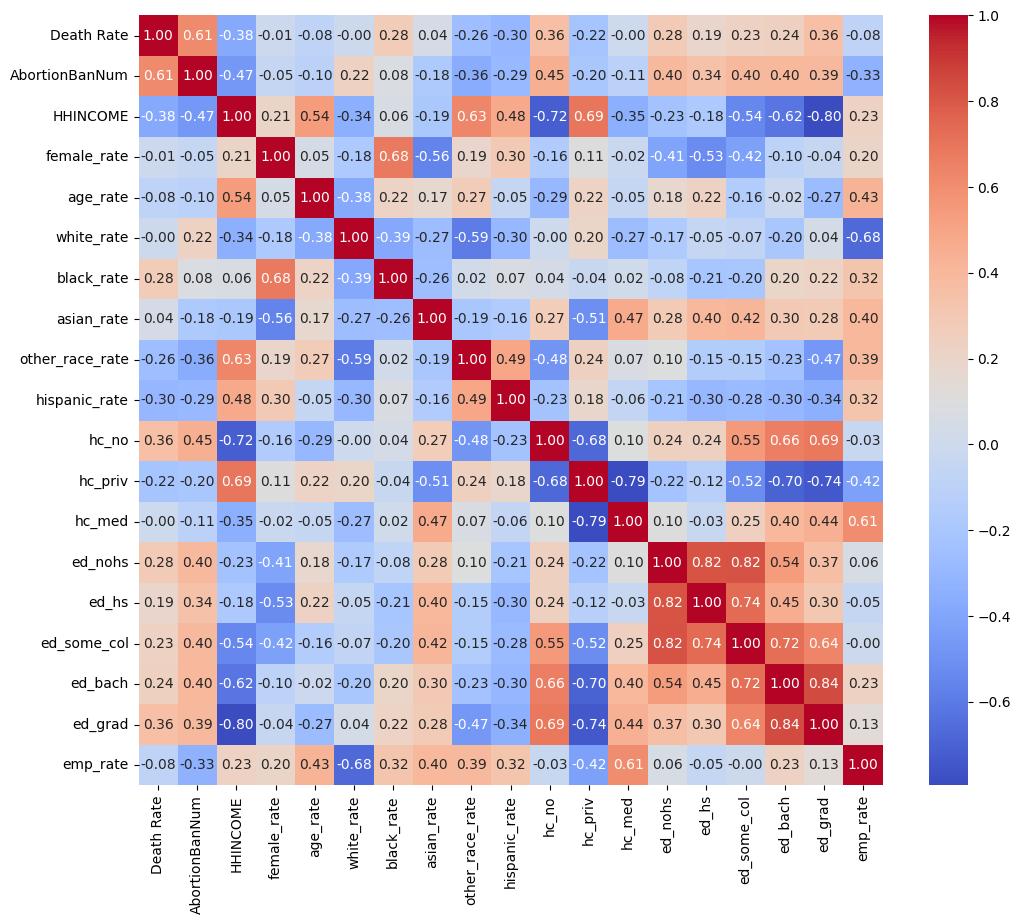

```python
# Importing the necessary libraries
import seaborn as sns
import matplotlib.pyplot as plt

# Calculating the correlation matrix for the selected columns
corr_matrix = df[['Death Rate', 'AbortionBanNum', 'HHINCOME', 'female_rate', 'age_rate',
                  'white_rate', 'black_rate', 'asian_rate', 'other_race_rate', 'hispanic_rate',
                  'hc_no', 'hc_priv', 'hc_med', 'ed_nohs', 'ed_hs', 'ed_some_col', 'ed_bach',
                  'ed_grad', 'emp_rate']].corr()

# Setting up the figure size for better readability
plt.figure(figsize=(12, 10))

# Creating the heatmap with adjusted parameters
sns.heatmap(corr_matrix, annot=True, cmap='coolwarm', fmt='.2f', annot_kws={'size': 10})

# Displaying the plot
plt.show()
```

### **2.1 Key Observations**

#### **Abortion Ban Number and Death Rate**

There is a moderate positive correlation (0.61) between `AbortionBanNum` and `Death Rate`, suggesting that states with more abortion bans tend to have higher death rates.

#### **Employment Rate**

Employment rate (`emp_rate`) has a small negative correlation with `Death Rate` (-0.08), indicating that higher employment is weakly associated with lower death rates, although this correlation is not very strong.

## **3. Abortion Ban Restrictiveness vs Average Infant Mortality Rate**

This line chart plots the average infant mortality rate against the abortion ban restrictiveness across states. The purpose of this plot is to visualize the relationship between the independent variable (`AbortionBanNum`) and the dependent variable (`Death Rate`). It helps identify the potential trend or pattern that will guide the interpretation of regression results. If this relationship is roughly linear, it will support the assumptions of a linear regression model, making it an important preliminary visualization for understanding the data before fitting the model.

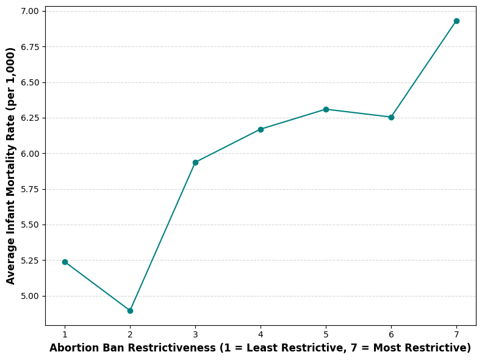

```python
# Grouping by Abortion Ban Restrictiveness and calculate the average Death Rate
ban_avg = df.groupby("AbortionBanNum")["Death Rate"].mean().reset_index()

# Plotting a line chart
plt.figure(figsize=(8, 6))
plt.plot(ban_avg["AbortionBanNum"], ban_avg["Death Rate"], marker='o', color='teal', linestyle='-')
plt.xlabel("Abortion Ban Restrictiveness (1 = Least Restrictive, 7 = Most Restrictive)", fontsize=12, fontweight='bold')
plt.ylabel("Average Infant Mortality Rate (per 1,000)", fontsize=12, fontweight='bold')
plt.grid(axis="y", linestyle="--", alpha=0.5)


plt.tight_layout()
plt.show()
```

### **3.1 Key Observations**

#### **Outliers**

The highest mortality rate appears at the most restrictive end (category 7), suggesting a potential outlier, or it could represent a meaningful data point showing the worst health outcomes associated with these policies.

### **Insights and Implications**

This line chart shows a clear upward trend between abortion ban restrictiveness and infant mortality rates, suggesting that stricter abortion laws are associated with higher mortality rates. This relationship is critical for the regression model, as it supports the hypothesis that states with more restrictive abortion policies could experience worse public health outcomes. The increase in mortality rates from categories 3-7 highlights that restrictive policies may lead to adverse health outcomes, potentially due to limited access to reproductive healthcare. These insights suggest that addressing abortion restrictions could be an important factor in improving infant mortality rates and public health more broadly, reinforcing the importance of incorporating abortion policy severity as a predictor in the regression model.

## **4. Abortion Ban Restrictiveness and Infant Mortality Rate by Region**

This bar chart compares Abortion Ban Restrictiveness and Infant Mortality Rates across different regions in the U.S. By showing the relationship between abortion policy severity and health outcomes regionally, this visualization helps to identify regional patterns or differences. These differences could play an important role in the regression model, where regional variables or interaction terms may be used to account for varying effects of abortion policies on infant mortality across the country. The regions with higher abortion bans and mortality rates could suggest that regional factors—such as healthcare access, socioeconomic conditions, or state-level policies—are influencing the results.

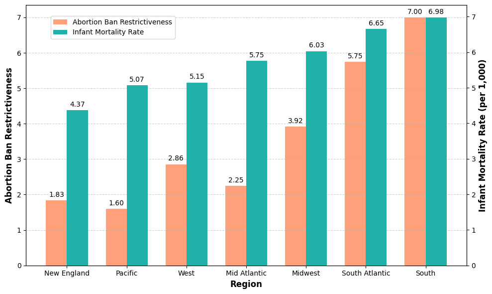

```python
import numpy as np

# Grouping data by region
df_grouped_region = df.groupby('Region').agg(
    AbortionBanNum=('AbortionBanNum', 'mean'),
    DeathRate=('Death Rate', 'mean')
).reset_index()

# Sorting by average Death Rate
df_grouped_region = df_grouped_region.sort_values(by='DeathRate', ascending=True)

# Extracting data for plotting
x = df_grouped_region['Region']
abortion_ban_means = df_grouped_region['AbortionBanNum']
infant_mortality_means = df_grouped_region['DeathRate']

# Setting bar positions and width
bar_width = 0.35
bar_positions = np.arange(len(x))

# Plotting
fig, ax1 = plt.subplots(figsize=(10, 6))

# Primary axis (Abortion Ban Severity)
bars1 = ax1.bar(
    bar_positions - bar_width / 2,
    abortion_ban_means,
    bar_width,
    label='Abortion Ban Restrictiveness',
    color='#FFA07A'  # Light Coral
)
ax1.set_ylabel('Abortion Ban Restrictiveness', fontsize=12, fontweight='bold')
ax1.tick_params(axis='y')

# Secondary axis (Infant Mortality Rate)
ax2 = ax1.twinx()
bars2 = ax2.bar(
    bar_positions + bar_width / 2,
    infant_mortality_means,
    bar_width,
    label='Infant Mortality Rate',
    color='#20B2AA'  # Light Sea Green
)
ax2.set_ylabel('Infant Mortality Rate (per 1,000)', fontsize=12, fontweight='bold')
ax2.tick_params(axis='y')

# Adding value labels on bars
for bar in bars1:
    ax1.text(
        bar.get_x() + bar.get_width() / 2,
        bar.get_height() + 0.1,
        f'{bar.get_height():.2f}',
        ha='center',
        fontsize=10
    )
for bar in bars2:
    ax2.text(
        bar.get_x() + bar.get_width() / 2,
        bar.get_height() + 0.1,
        f'{bar.get_height():.2f}',
        ha='center',
        fontsize=10
    )

ax1.set_xlabel('Region', fontsize=12, fontweight='bold')
ax1.set_xticks(bar_positions)
ax1.set_xticklabels(x, fontsize=10)
ax1.grid(axis='y', linestyle='--', alpha=0.6)

# Adding legend inside the graph with custom position
fig.legend(
    [bars1, bars2],
    ['Abortion Ban Restrictiveness', 'Infant Mortality Rate'],
    loc='upper left',
    bbox_to_anchor=(0.1, 0.95),
    fontsize=10,
    ncol=1
)

# Creating tight layout for better spacing
plt.tight_layout()
plt.show()
```

### **4.1 Key Observations**

#### **Consistent Trend**

There appears to be a consistent positive correlation between the levels of abortion ban restrictiveness and infant mortality rates, particularly in the regions with the highest and lowest restrictiveness.

### **Insights and Implications**

This bar chart reinforces the idea that stricter abortion policies tend to be associated with higher infant mortality rates, particularly in the South and South Atlantic regions. The South, with the highest abortion restrictions, shows the highest mortality rates, while the New England and Pacific regions, which are less restrictive, show lower mortality rates. These regional differences highlight the importance of considering regional effects in the regression model, as the relationship between abortion policies and public health may not be uniform across the country. Socioeconomic factors, healthcare access, and state-level variations in policy enforcement could be playing significant roles, and these factors should be carefully analyzed in the model to provide more nuanced insights into the impact of abortion laws on health outcomes.

# **V. Model**

## **Model Specification**

The regression model will be specified as follows:

## **Model Implementation**

```python
from sklearn.linear_model import LinearRegression
from sklearn.preprocessing import StandardScaler
from sklearn.metrics import r2_score
import statsmodels.api as sm

# Ensuring 'Region' is categorical and reordering it to set 'Mid Atlantic' as the reference
df['Region'] = pd.Categorical(
    df['Region'],
    categories=['Mid Atlantic', 'New England', 'Midwest', 'Pacific', 'South', 'South Atlantic', 'West'],
    ordered=True
)

# Preprocessing: Creating dummy variables for region
region_dummies = pd.get_dummies(df['Region'], drop_first=True)

# Forcing region dummies to be numeric (int or float)
region_dummies = region_dummies.astype(int)  # or float if needed

# Selecting continuous variables to standardize, including AbortionBanNum, income, and other controls
continuous_vars = ['AbortionBanNum', 'HHINCOME', 'female_rate', 'age_rate', 'white_rate', 'black_rate',
                   'asian_rate', 'other_race_rate', 'hispanic_rate', 'emp_rate', 'ed_nohs', 'ed_hs',
                   'ed_some_col', 'ed_bach', 'ed_grad']

# Creating the features dataframe with continuous and dummy variables
X = pd.concat([df[continuous_vars], region_dummies], axis=1)

# Standardizing the continuous variables
scaler = StandardScaler()
X_scaled = scaler.fit_transform(X[continuous_vars])

# Recombining the scaled continuous variables with the region dummies (which stay unscaled)
X_scaled_full = pd.concat([pd.DataFrame(X_scaled, columns=continuous_vars), region_dummies], axis=1)

# Defining the dependent variable (Infant Mortality Rate or Death Rate)
y = df['Death Rate']

# Fitting the regression model
model = LinearRegression()
model.fit(X_scaled_full, y)

# Predictions and R-squared
y_pred = model.predict(X_scaled_full)
r2 = r2_score(y, y_pred)

# Printing results
print("R-squared:", r2)
print("Coefficients:", model.coef_)
print("Intercept:", model.intercept_)

# Using statsmodels for detailed summary
X_sm = sm.add_constant(X_scaled_full)  # Adding constant for intercept
sm_model = sm.OLS(y, X_sm).fit()
print(sm_model.summary())
```

```
R-squared: 0.6803039920047105
Coefficients: [ 0.76097286 -0.02351548 -0.28436044 -0.24303022  0.01252912  0.5501789
  0.43197899  0.41647267 -0.1039604  -0.00262298  0.14385339 -0.09533368
 -0.23732956 -0.63401192  0.51603084 -1.21338793  0.14392226 -0.64235195
  0.22180509 -0.03460989 -0.50406569]
Intercept: 5.980949579449977
                            OLS Regression Results
==============================================================================
Dep. Variable:             Death Rate   R-squared:                       0.680
Model:                            OLS   Adj. R-squared:                  0.441
Method:                 Least Squares   F-statistic:                     2.837
Date:                Thu, 12 Dec 2024   Prob (F-statistic):            0.00532
Time:                        01:22:56   Log-Likelihood:                -54.358
No. Observations:                  50   AIC:                             152.7
Df Residuals:                      28   BIC:                             194.8
Df Model:                          21
Covariance Type:            nonrobust
===================================================================================
                      coef    std err          t      P>|t|      [0.025      0.975]
-----------------------------------------------------------------------------------
const               5.9809      0.447     13.385      0.000       5.066       6.896
AbortionBanNum      0.7610      0.255      2.986      0.006       0.239       1.283
HHINCOME           -0.0235      0.449     -0.052      0.959      -0.943       0.896
female_rate        -0.2844      0.331     -0.858      0.398      -0.963       0.394
age_rate           -0.2430      0.305     -0.796      0.433      -0.869       0.383
white_rate          0.0125      0.325      0.039      0.970      -0.653       0.678
black_rate          0.5502      0.341      1.613      0.118      -0.149       1.249
asian_rate          0.4320      0.358      1.208      0.237      -0.301       1.165
other_race_rate     0.4165      0.384      1.083      0.288      -0.371       1.204
hispanic_rate      -0.1040      0.240     -0.433      0.668      -0.596       0.388
emp_rate           -0.0026      0.331     -0.008      0.994      -0.681       0.676
ed_nohs             0.1439      0.487      0.295      0.770      -0.853       1.141
ed_hs              -0.0953      0.353     -0.270      0.789      -0.819       0.628
ed_some_col        -0.2373      0.546     -0.435      0.667      -1.355       0.881
ed_bach            -0.6340      0.381     -1.666      0.107      -1.414       0.146
ed_grad             0.5160      0.438      1.178      0.249      -0.381       1.413
New England        -1.2134      0.612     -1.982      0.057      -2.468       0.041
Midwest             0.1439      0.621      0.232      0.818      -1.128       1.416
Pacific            -0.6424      0.816     -0.787      0.438      -2.314       1.029
South               0.2218      0.745      0.298      0.768      -1.305       1.749
South Atlantic     -0.0346      0.807     -0.043      0.966      -1.687       1.618
West               -0.5041      0.588     -0.858      0.398      -1.708       0.700
==============================================================================
Omnibus:                        0.226   Durbin-Watson:                   2.437
Prob(Omnibus):                  0.893   Jarque-Bera (JB):                0.008
Skew:                          -0.027   Prob(JB):                        0.996
Kurtosis:                       3.028   Cond. No.                         22.3
==============================================================================

Notes:
[1] Standard Errors assume that the covariance matrix of the errors is correctly specified.
```

## **Key Observations**

### **Model Fit**

The R-squared value is 0.680, meaning the model explains about 68% of the variation in Death Rate (or Infant Mortality Rate). The Adjusted R-squared value of 0.441 is lower, indicating that the model could benefit from either additional variables or refinement.

### **Abortion Ban Restrictiveness**

The coefficient for `AbortionBanNum` is 0.7610, with a p-value of 0.006, which is statistically significant at the 1% level. This suggests that stricter abortion bans are associated with higher death rates (or higher infant mortality rates), supporting the hypothesis that restrictive abortion policies may negatively impact public health.

### **Income**

The `HHINCOME` coefficient is -0.0235, with a p-value of 0.959, indicating that income does not significantly affect death rates in this model. This suggests that, in this context, household income is not a strong determinant of infant mortality, possibly due to other underlying factors or the limitations of this model.

### **Demographic Variables**

Female rate (`female_rate`) and age rate (`age_rate`) are not statistically significant, as their p-values are above the conventional threshold of 0.05. This indicates that gender and age distribution do not significantly affect the infant mortality rate in this model. Similarly, racial demographic variables such as `white_rate`, `black_rate`, `asian_rate`, `other_race_rate`, and `hispanic_rate` show mixed results. While `black_rate` and `asian_rate` have relatively higher t-statistics, they still do not reach statistical significance at the 5% level.

### **Education**

The coefficients for education levels (`ed_nohs`, `ed_hs`, `ed_some_col`, `ed_bach`, `ed_grad`) also do not show strong significance, indicating that education may not have a substantial impact on death rates in this model, or again, the model might need further refinement to capture this relationship more effectively.

## **Insights and Implications**

The model shows that abortion ban restrictiveness has a statistically significant positive relationship with death rates (or infant mortality rates), meaning more restrictive abortion policies tend to be associated with worse public health outcomes. The findings emphasize the potential public health consequences of restrictive abortion policies, supporting the argument that such policies could exacerbate mortality rates.

The lack of significance for income and education suggests that, within the context of this model, these factors may not be as strongly correlated with infant mortality as expected. This could point to the need for more nuanced modeling, or the inclusion of interaction terms or other relevant variables (such as healthcare access) to more accurately capture the influence of socioeconomic factors.

The regional differences, particularly the negative coefficient for New England, imply that regional policies, healthcare access, or other state-level factors might play a significant role in reducing infant mortality rates, and that these factors should be further explored.

Ultimately, this model underscores the importance of considering abortion policies in the context of public health outcomes, but also highlights the need for further refinement to better capture the full range of factors influencing infant mortality. Future research could include additional controls for healthcare systems, public health infrastructure, or state-specific policies to deepen the understanding of these relationships.

## **Visualization:Regression Line Plot: Abortion Ban Restrictiveness vs. Infant Mortality Rate**

This plot is used to visually assess the relationship between abortion ban restrictiveness (as measured by `AbortionBanNum`) and infant mortality rate (or `Death Rate`). By including the regression line, we can observe the trend and strength of this relationship. It is particularly important to see if the linear regression model's fit aligns with the data and if the assumptions of a linear relationship hold true.

The goal is to understand how the restrictiveness of abortion laws (ranging from least restrictive to most restrictive) influences infant mortality rates. This plot helps assess if there is a clear upward or downward trend, which could support or challenge the hypothesis that more restrictive abortion laws are linked to higher mortality rates. The red regression line illustrates the model's best fit, and the shaded area provides confidence intervals for the predictions.

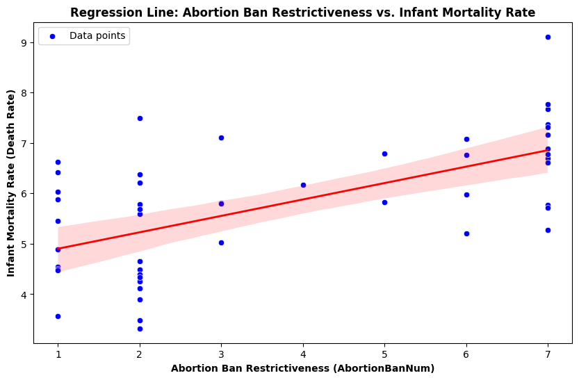

```python
# Creating a scatter plot
plt.figure(figsize=(10, 6))
sns.scatterplot(x='AbortionBanNum', y='Death Rate', data=df, color='blue', label='Data points')

# Fitting a linear regression line using seaborn's regplot
sns.regplot(x='AbortionBanNum', y='Death Rate', data=df, scatter=False, color='red', line_kws={"color": "red", "lw": 2})

# Adding labels and title
plt.title('Regression Line: Abortion Ban Restrictiveness vs. Infant Mortality Rate', fontweight = 'bold')
plt.xlabel('Abortion Ban Restrictiveness (AbortionBanNum)', fontweight = 'bold')
plt.ylabel('Infant Mortality Rate (Death Rate)', fontweight = 'bold')
plt.legend()

# Displaying the plot
plt.show()
```

## **Key Observations: Visualization**

The **red regression line** shows a clear upward trend in infant mortality rates as **abortion ban restrictiveness** increases. **Data points (blue)** are scattered, with some regions showing much higher mortality rates despite having lower abortion ban restrictiveness. The plot indicates that **states with higher abortion ban restrictiveness** (toward the right side of the x-axis) tend to have **higher infant mortality rates**.

# **VI. Conclusion**

This analysis explored the relationship between state-level abortion ban restrictiveness and infant mortality rates across the United States, using data from multiple sources, including the Guttmacher Institute, CDC WONDER, and IPUMS. The results of the linear regression model suggest a significant positive relationship between stricter abortion laws and higher infant mortality rates. Specifically, as abortion restrictions increase, so do the rates of infant deaths, particularly in the South and South Atlantic regions, which show the highest levels of abortion ban severity and the highest mortality rates.

The model provided valuable insights into the potential public health consequences of restrictive abortion policies, emphasizing the need for more evidence-based policymaking. However, despite the significant findings, the model's relatively low R-squared value indicates that other unaccounted factors may also contribute to the observed outcomes. These could include healthcare infrastructure, access to maternal and child health services, and socio-economic disparities across states. Future research could refine this model by incorporating additional control variables, such as access to prenatal care, healthcare provider density, and state-level healthcare policy initiatives.

In conclusion, this analysis underscores the importance of considering the broader societal impacts of abortion policy on public health. The findings suggest that while stricter abortion laws may be intended to limit reproductive choices, they may inadvertently contribute to higher infant mortality rates. Addressing these policies, alongside improvements in healthcare access, socio-economic conditions, and education, could lead to improved health outcomes for both mothers and infants across the country. Further research and refined models will be essential to fully understand the complex relationship between abortion restrictions and public health outcomes, guiding future efforts for policy reform.

# **VII. Citations and Articles of Interest**

Chapman I. Texas' Abortion Ban Linked to Rising Infant Mortality Rates. *CNN*. Published July 20, 2023. https://www.cnn.com/2023/07/20/health/texas-abortion-ban-infant-mortality-invs/index.html.

[Webpage Link](https://www.cnn.com/2023/07/20/health/texas-abortion-ban-infant-mortality-invs/index.html)

Moayedi G, Osamba A, Koyama A. Abortion Bans Harm Not Just Pregnant People—They Harm Newborns and Infants Too. JAMA Pediatr. 2024;178(8):748-750. doi:10.1001/jamapediatrics.2024.1792

[Webpage Link](https://jamanetwork.com/journals/jamapediatrics/article-abstract/2819789?widget=personalizedcontent&previousarticle=2825201)

Singh P, Gallo MF. National Trends in Infant Mortality in the US After Dobbs. JAMA Pediatr. 2024;178(12):1364-1366. doi:10.1001/jamapediatrics.2024.4276

[Webpage Link](https://jamanetwork.com/journals/jamapediatrics/article-abstract/2825201?utm_campaign=articlePDF&utm_medium=articlePDFlink&utm_source=articlePDF&utm_content=jamapediatrics.2024.4276#google_vignette)

# **VIII. Converting ipynb file into HTML**

```python
!jupyter nbconvert --to html /content/drive/MyDrive/index.ipynb
```

```
[NbConvertApp] Converting notebook /content/drive/MyDrive/index.ipynb to html
[NbConvertApp] Writing 511471 bytes to /content/drive/MyDrive/index.html
```

```python
!jupyter nbconvert --to html --embed-images index.ipynb
```

```
[NbConvertApp] Converting notebook index.ipynb to html
[NbConvertApp] Writing 511471 bytes to index.html
```